# assignment1answers

**Data set up**

```r
library(forecast)

dt <- read.csv("GoldPrice.csv")

# End of estimation sample
EndSample <- c(2021, 12)
# End of forecast period
EndForecast <- c(2022, 12)

# Gold price time series
GoldPrice <- ts(dt$GoldPrice,
                frequency = 12,
                start = c(2000, 1),
                end = EndForecast)

# log gold price
Y <- log(GoldPrice)
Time <- time(Y)

# Observation indices for estimation sample
ts <- which((dt$Year < EndSample[1]) |
              (dt$Year == EndSample[1] & dt$Month <= EndSample[2]))
n <- length(ts)

# Observation indices for forecast period
tf <- (n + 1):length(Y)
```

1. The time series plot of the log gold price is shown below. Evidently there is a general increasing trend, but this is clearest from 2000 until sometime around 2012. Thereafter the time series drifts without such a clear direction. Instead there are some prolonged periods (over multiple years) where the price drifts upwards or downwards. There is no sign of a seasonal pattern, and one will not be included in the modelling here.

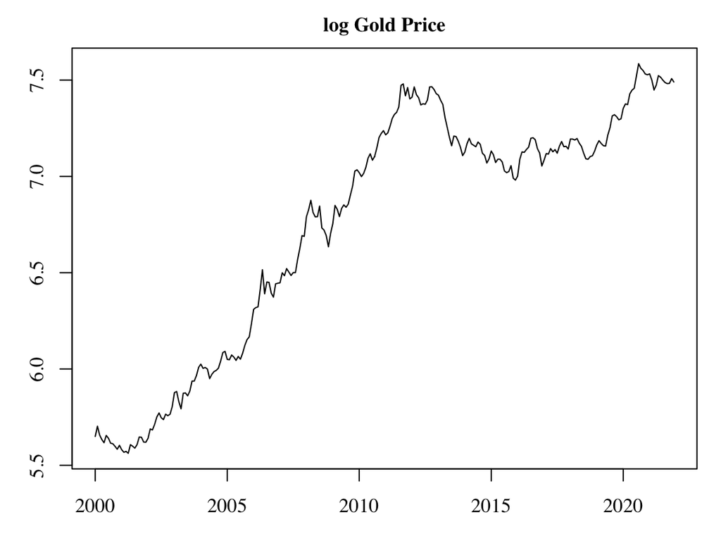

   ```r
   plot(Time[ts], Y[ts], type = "l", main = "log Gold Price")
   ```

2. 1. The following shows the linear trend estimation and plot.

      ```r
      ## Fit linear trend and plot
      dt$Y <- Y
      dt$Time <- Time
      eq0 <- lm(Y ~ Time, data = dt[ts, ])
      ```

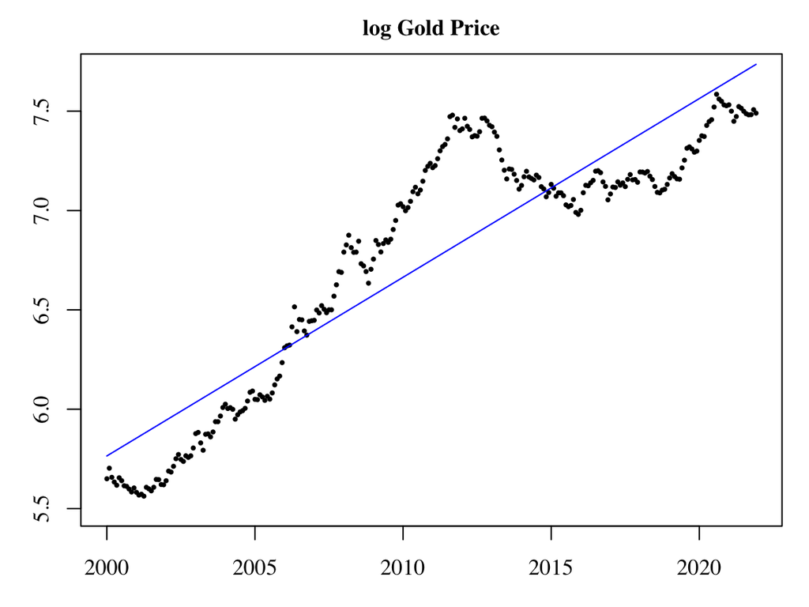

      ```r
      plot(Time[ts], Y[ts], pch = 16, cex = 0.5)
      lines(Time[ts], eq0$fitted, col = "blue")
      ```

      While it’s clear the linear trend provides a first approximation to the upwards trend in the time series, it’s also clear a linear trend misses the way in which the trend changes or disappears around the early 2010’s. The trend is not positive enough prior to the early 2010’s, but too positive thereafter.
   2. The following code shows how AR lag length selection can be carried out with a linear trend included. For each lag length $p$ the model is estimated, Ljung-Box autocorrelation test computed, and AICc saved. The choice of lag length $p$ to minimise the AICc is noted, and the $p$-value of the Ljung-Box autocorrelation test for that choice of lag length checked.

      ```r
      ### Set max lag and storage for AIC and Ljung-Box tests
      pmax <- 12
      Stats <- matrix(nrow = pmax + 1, ncol = 3)
      colnames(Stats) <- c("p", "AICc", "LBp")

      for (p in 0:pmax){

        ARp <- Arima(Y[ts],
                     order = c(p, 0, 0),
                     xreg = Time[ts])

        LBp <- Box.test(ARp$residuals,
                        lag = 12,
                        type = "Ljung-Box",
                        fitdf = p)$p.value

        Stats[p + 1, ] <- c(p, ARp$aicc, LBp)

      }

      # Find lag length that minimises AICc
      r <- which.min(Stats[, "AICc"])
      p0 <- Stats[r, "p"]
      ```

      The lag length for the AR model to minimise the AICc is:

      ```
        p0 = 2
      ```

      The Ljung-Box test $p$ value is:

      ```r
      # Ljung-Box p-value for AR(p0) model
      LBp <- Stats[r, "LBp"]
      ```

      ```
        LBp = 0.163
      ```

      Since the Ljung-Box *p*-value for the AICc-selected AR(2) model is not less than 0.05, we can conclude there is no evidence the model is misspecified. The AR(2) model with linear trend will be subsequently used for forecasting.

      The estimation of this model is as follows, with the coefficient estimates shown.

      ```r
      AR2 <- Arima(Y[ts],
                   order = c(p0, 0, 0),
                   xreg = Time[ts])
      print(coef(AR2))
      ```

      ```
                ar1           ar2     intercept          xreg
         1.12689596   -0.13871429 -165.09477158    0.08542264
      ```

      In equation form:
      $$\begin{aligned}
      Y_t &= -165.095 +0.085 \: \text{Time}_t + \widehat{Z}_t \\
      \widehat{Z}_t &=
      1.127 \: \widehat{Z}_{t-1}
      -0.139 \: \widehat{Z}_{t-2}
      + \widehat{U}_t
      \end{aligned}$$
3. 1. Choose the trend break point within start of 2010 to end of 2014.

      ```r
      # Specify range for possible break dates
      Break_range <- dt$Time[which(dt$Time >= 2010 & dt$Time < 2015)]

      # Storage for RSS
      RSS <- matrix(nrow = length(Break_range), ncol = 2)
      colnames(RSS) <- c("b", "RSS")
      RSS[, "b"] <- Break_range

      # For each break point, estimate trend equation and store RSS
      for (b in Break_range){
        dt$TB_b <- (dt$Time > b) * (dt$Time - b)
        eq1 <- lm(Y ~ Time + TB_b, data = dt[ts, ])
        RSS[which(RSS[, "b"] == b), "RSS"] <- sum(eq1$residuals^2)
      }

      # Choose break point b to that minimises RSS
      b <- RSS[which.min(RSS[, "RSS"]), "b"]
      ```

      ```
        b = 2011.41666666667
      ```

      Since the month and year for each observation are in the dataframe, it is simple to show the month and year corresponding to the estimated breakpoint:

      ```r
      print(dt[which(dt$Time == b), c("Month", "Year")])
      ```

      ```
       Month Year
           6 2011
      ```

   2. Fit linear trend with break at estimated time.

      ```r
      dt$TB_b <- (dt$Time > b) * (dt$Time - b)
      eq1 <- lm(Y ~ Time + TB_b, data = dt[ts, ])
      ```

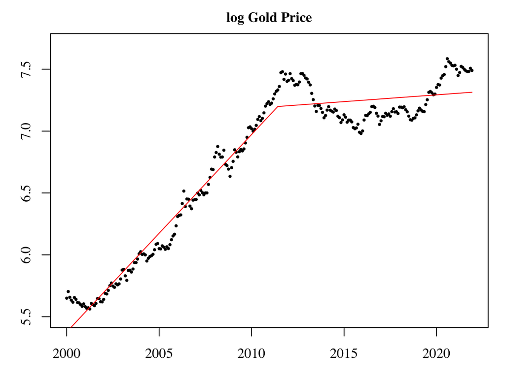

      ```r
      plot(Time[ts], Y[ts], pch = 16, cex = 0.5)
      lines(Time[ts], eq1$fitted, col = "red")
      ```

      Allowing for a break in the trend in June 2011 results in an estimated trend that visually better captures the general direction of the time series over both halves of the sample.
   3. The code for AR order selection is as follows, with the same logic as in question 2.

      ```r
      X1 <- as.matrix(dt[, c("Time", "TB_b")])

      pmax <- 12
      Stats <- matrix(nrow = pmax + 1, ncol = 3)
      colnames(Stats) <- c("p", "AICc", "LBp")

      for (p in 0:pmax){
        ARp <- Arima(Y[ts],
                     order = c(p, 0, 0),
                     xreg = X1[ts, ])

        LBp <- Box.test(ARp$residuals, lag = 12,
                        type = "Ljung-Box",
                        fitdf = p)$p.value

        Stats[p + 1, ] <- c(p, ARp$aicc, LBp)
      }

      # Find lag length that minimises AICc
      r <- which.min(Stats[, "AICc"])
      p1 <- Stats[r, "p"]
      ```

      The selected lag length for the AR model with trend and break is:

      ```
        p1 = 3
      ```

      ```r
      # Ljung-Box p-value for AR(p1) model
      LBp <- Stats[r, "LBp"]
      ```

      ```
        LBp = 0.225
      ```

      Since the Ljung-Box *p*-value for the AICc-selected AR(3) model is not less than 0.05, we can conclude there is no evidence the model is misspecified.

      The estimation of this model is as follows, with the coefficient estimates shown.

      ```r
      AR3_TB <- Arima(Y[ts],
                      order = c(p1, 0, 0),
                      xreg = X1[ts, ])
      print(round(coef(AR3_TB), 3))
      ```

      ```
            ar1       ar2       ar3 intercept      Time      TB_b
          1.109    -0.237     0.092  -288.206     0.147    -0.125
      ```

      In equation form:
      $$\begin{aligned}
      Y_t &= -288.206
      +0.147 \: \text{Time}_t
      -0.125 \: \text{TB}_t(b)
      + \widehat{Z}_t \\
      \widehat{Z}_t &=
      1.109 \: \widehat{Z}_{t-1}
      -0.237 \: \widehat{Z}_{t-2}
      +0.092 \: \widehat{Z}_{t-3}
      + \widehat{U}_t
      \end{aligned}$$
4. The code to carry out the one-step-ahead estimation and forecasts is shown below.

   ```r
   # Storage for forecasts from both models
   AR2_f1 <- ts(start = c(2000, 1), end = EndForecast, frequency = 12)
   AR3_TB_f1 <- ts(start = c(2000, 1), end = EndForecast, frequency = 12)

   # Increase end of sample one period at a time through forecast period
   for (n in (tf - 1)){

     # Estimation sample
     t <- 1:n

     # AR(2) + Trend : estimation and one-step-ahead forecast
     AR2 <- Arima(Y[t],
                  order = c(p0, 0, 0),
                  xreg = Time[t])
     AR2_f1[n + 1] <- forecast(AR2, xreg = Time[n + 1])$mean

     # AR(3) + Trend + Break : estimation and one-step-ahead forecast
     AR3_TB <- Arima(Y[t],
                     order = c(p1, 0, 0),
                     xreg = X1[t, ])
     AR3_TB_f1[n + 1] <- forecast(AR3_TB,
                                  xreg = X1[n + 1, , drop = FALSE])$mean

   }
   Forecasts <- cbind(AR2_f1 = AR2_f1[tf], AR3_TB_f1 = AR3_TB_f1[tf])
   ```

   The forecasts for the two models are tabulated below.

   ```
             AR2_f1 AR3_TB_f1
     2022m1  7.4955    7.4834
     2022m2  7.5142    7.5061
     2022m3  7.5371    7.5261
     2022m4  7.5889    7.5771
     2022m5  7.5757    7.5613
     2022m6  7.5233    7.5141
     2022m7  7.5225    7.5179
     2022m8  7.4569    7.4486
     2022m9  7.4860    7.4827
     2022m10 7.4281    7.4186
     2022m11 7.4237    7.4198
     2022m12 7.4658    7.4585
   ```

   The accuracy of these two sets of forecasts are evaluated using Root Mean Square Errors:

   ```r
   ForecastErrors <- Y[tf] - Forecasts
   RMSE <- round(sqrt(apply(ForecastErrors^2, 2, mean)), 4)
   ```

   There is a very small accuracy advantage for the AR(3) model with trend break included.

   ```
            AR2_f1 AR3_TB_f1
     RMSE:  0.0351    0.0349
   ```

   The plot of the actual values for 2022 together with the two sets of forecasts is shown below. As reflected in the very close RMSE values, there is little to choose between the sets of forecasts. The linear trend + AR(2) model produces slightly larger forecasts, which makes sense since omitting the break results in a trend that is too positive in the latter part of the sample. But, at least for one-step-ahead forecasts, the difference is minor.

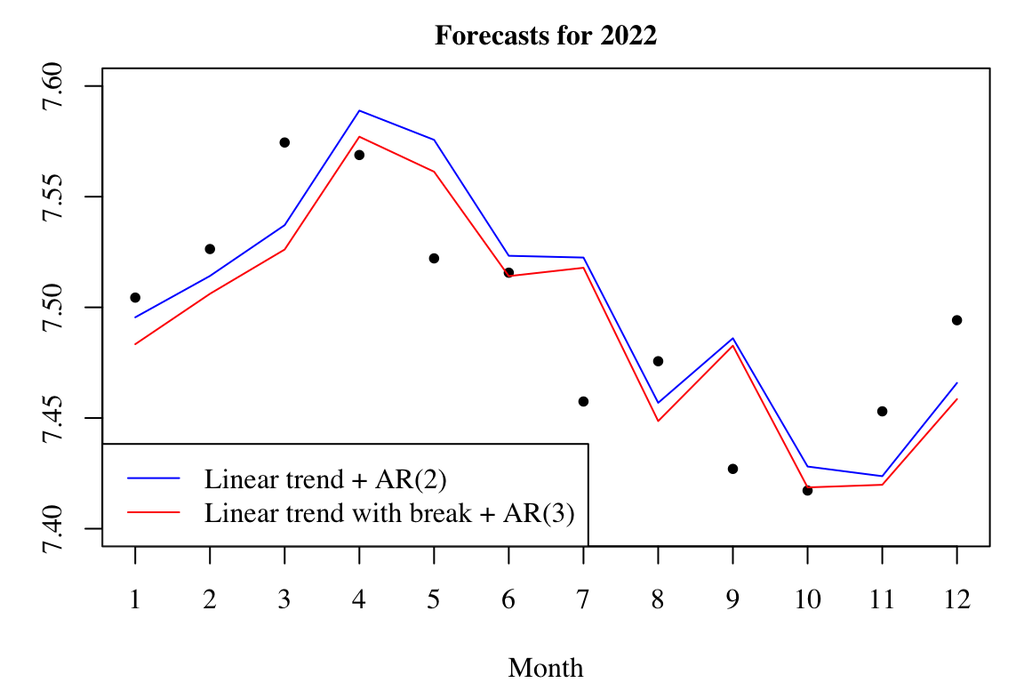